# Més demanda, les mateixes places, notes de tall més altes

L’accés a les universitats públiques de Catalunya (preinscripció 2016–2025)

Publicat

30 de juliol del 2026

## En síntesi

Entre **2020** i **2025**, el nombre de sol·licitants en primera preferència a les universitats públiques catalanes ha crescut un **13%** (de 55.815 a 63.038), mentre que l’oferta de places gairebé no s’ha mogut: només un **4%** més (de 40.213 a 41.801). Quan molta més gent es disputa pràcticament les mateixes places, el resultat és inevitable: **les notes de tall pugen**. La mediana de la nota de tall ha passat de 5,92 (2016) a 8,20 (2025), i cada cop hi ha menys estudis que s’omplen sense competència.

Aquests tres fets —més demanda, oferta estable i notes més altes— no són independents: formen **una sola cadena causal**. I no s’expliquen perquè l’alumnat arribi molt millor preparat: entre 2016 i 2025, la nota d’accés mitjana de qui es presenta a les PAU només ha pujat 0,14 punts, davant dels 2,28 que ha pujat la mediana del tall.

## 1. La demanda d’estudis creix

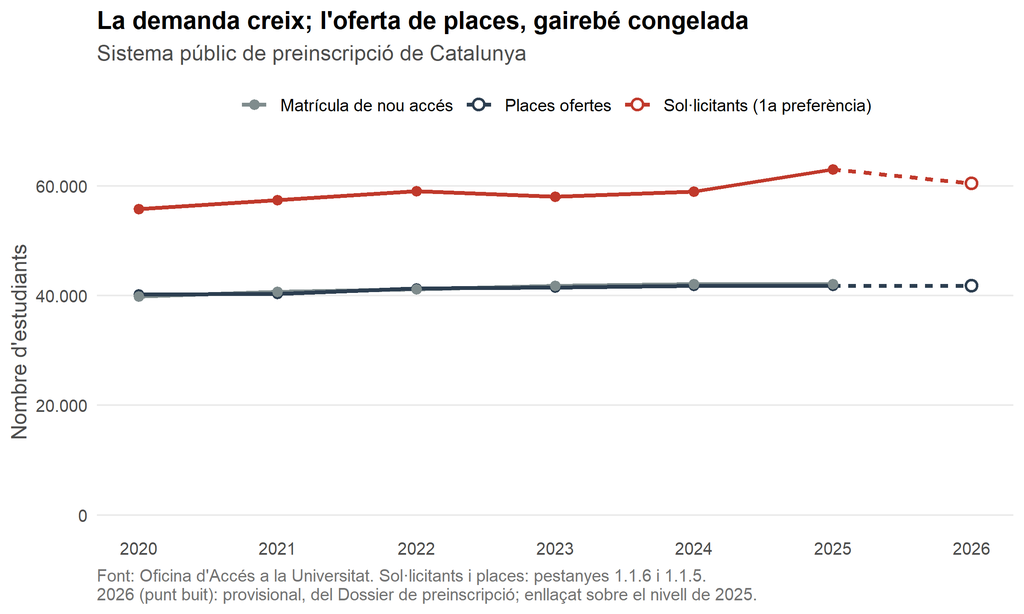

Figura 1

La línia vermella —els estudiants que demanen un grau públic en primera opció— puja de forma sostinguda. En canvi, la línia de **places** (blau fosc) és gairebé plana. La **matrícula de nou accés** (gris) segueix de prop les places: en un sistema amb *numerus clausus*, el nombre de matriculats està limitat per la capacitat, no per la demanda. Per això el senyal de creixement es veu, sobretot, en els **sol·licitants**.

El punt buit de **2026** és el primer descens després del màxim: amb dades encara provisionals, els sol·licitants baixen un **4%** (fins a uns 60.420), mentre l’oferta segueix plana. És un sol any i cal prendre’l amb cautela —surt del *Dossier de preinscripció* de juliol de 2026, no de les pestanyes que alimenten la resta de la sèrie, i s’ha enllaçat sobre el nivell ferm de 2025 (vegeu la nota metodològica)—, però és coherent amb el que fa preveure la demografia escolar: les cohorts que arriben a la universitat han deixat de créixer.

## 2. Les places es mantenen estables

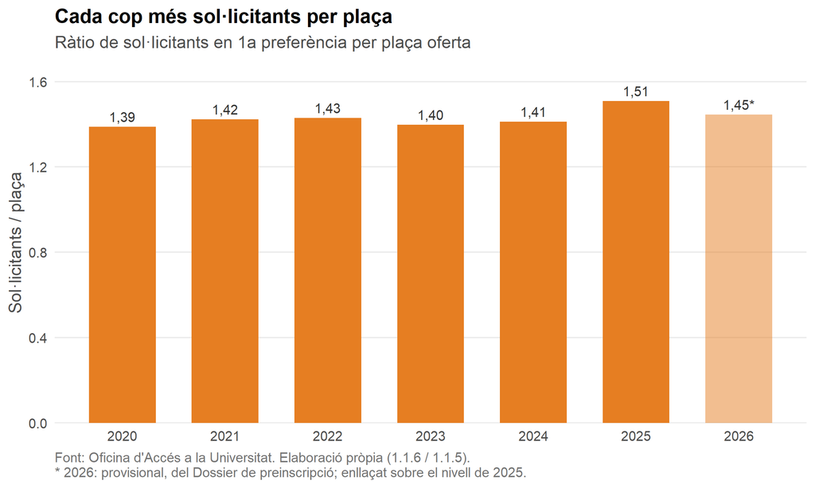

Figura 2

Amb una oferta gairebé congelada i una demanda creixent, la **pressió d’accés** —quants sol·licitants hi ha per cada plaça— augmenta. L’any 2020 hi havia 1,39 sol·licitants per plaça; el 2025, ja en són 1,51. No és que s’hagin retallat places (de fet han crescut lleugerament, sovint amb graus nous), sinó que **l’oferta no ha seguit el ritme de la demanda**.

## 3. Les notes de tall pugen

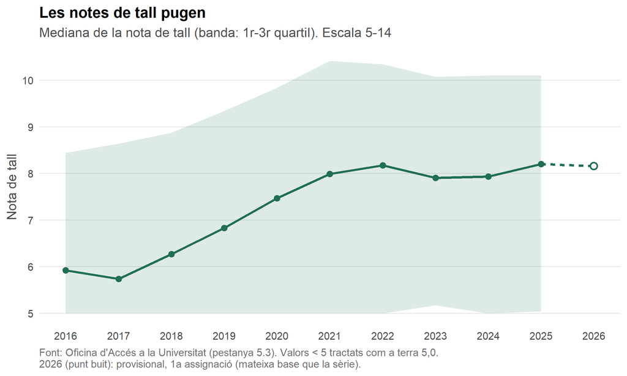

Figura 3

La conseqüència directa de tot plegat és que **entrar és més difícil**. La mediana de la nota de tall ha pujat de 5,92 a 8,20 punts (escala 5–14). La banda ombrejada mostra que la pujada no és d’uns pocs graus estrella, sinó de gairebé tota la distribució.

El punt buit de 2026 (provisional, de la **1a assignació** —la mateixa base que tota la sèrie) apunta un primer refredament coherent amb la caiguda de la demanda: la mediana baixa lleugerament (a 8,16) i tornen a créixer els estudis que s’omplen sense competència (de 138 a 147). El descens es concentra a la part alta —els graus amb nota de tall de 12 o més passen del 6% al 4%—, és a dir, just on la competència s’havia enfilat més.

### Quants estudis queden per damunt de cada llindar

La mediana resumeix el centre, però amaga com s’ha mogut la resta. Una manera de veure-ho és comptar **quina proporció d’estudis supera cada llindar de nota**.

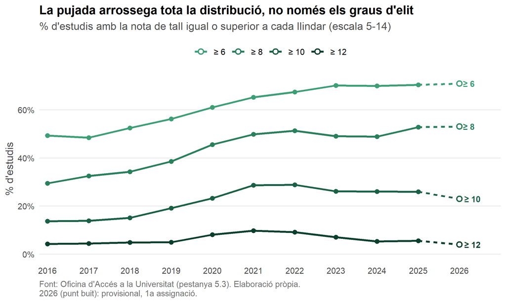

Figura 4

El gràfic mostra dos moviments ben diferents:

- **El gruix del sistema s’ha desplaçat cap amunt.** Els estudis que demanen un 8 o més han passat de ser una minoria (29% el 2016) a ser **majoria** (53% el 2025). Dit d’una altra manera: el 2016 en el 71% dels graus s’hi entrava amb menys d’un 8; el 2025, només en el 47%.
- **La part alta, en canvi, ha tocat sostre i ha reculat.** Els estudis amb una nota de tall de 12 o més van arribar al màxim el 2021 (10%) i ara són el 6%, poc més que el 4% del 2016.

Això matisa la lectura habitual. El que ha passat **no** és que un grapat de graus d’elit s’hagin tornat inabastables: és que **el mig del sistema ha pujat cap a on abans només hi havia els graus més demandats**. La competència no s’ha concentrat, s’ha **estès**.

% d’estudis amb la nota de tall igual o superior a cada llindar. Base: tots els estudis oferts cada any (468 el 2016, 555 el 2025).

| Nota de tall ≥ | 2016 | 2020 | 2025 | Canvi (pp) |
| --- | --- | --- | --- | --- |
| 6 | 49,4 | 61,0 | 70,5 | 21,1 |
| 7 | 40,6 | 53,3 | 64,7 | 24,1 |
| 8 | 29,5 | 45,5 | 52,8 | 23,3 |
| 9 | 19,7 | 36,2 | 38,4 | 18,7 |
| 10 | 13,7 | 23,3 | 25,9 | 12,2 |
| 11 | 9,4 | 16,5 | 14,8 | 5,4 |
| 12 | 4,3 | 8,1 | 5,6 | 1,3 |

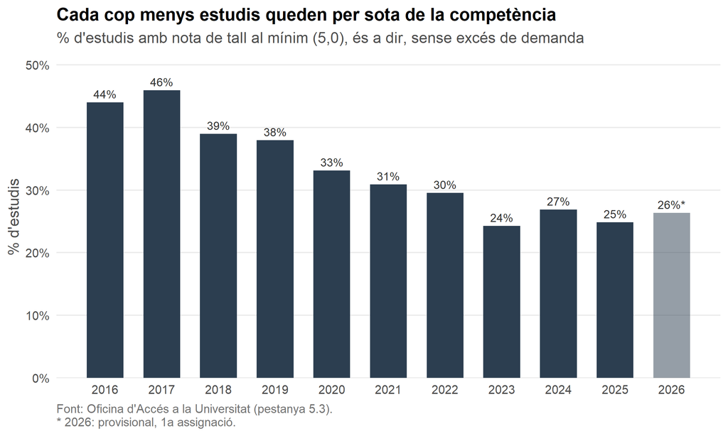

Figura 5

Un segon senyal apunta en la mateixa direcció: cada cop hi ha **menys estudis que s’omplen sense competència** (nota de tall al mínim de 5,0). Han passat de 206 estudis el 2016 a 138 el 2025. És a dir, la competència no només s’intensifica als graus més demandats, sinó que s’estén a una part més gran del sistema.

## 4. I les notes de l’alumnat? Pugen, però molt menys

Hi ha una explicació alternativa que val la pena posar a prova: potser les notes de tall pugen simplement perquè **l’alumnat arriba amb millors notes**. Si tothom té millor expedient, el llistó puja encara que la competència no canviï. Les dades de les PAU permeten separar les dues coses.

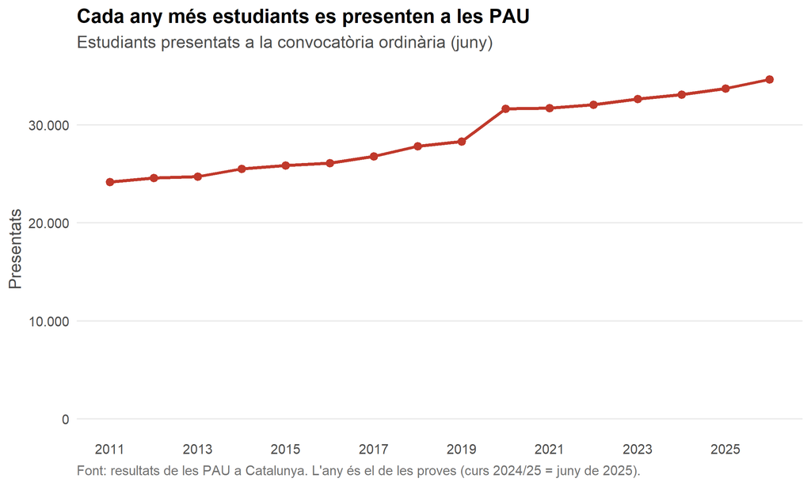

Figura 6

El primer que mostren és que **el col·lectiu que es presenta a les proves creix**: de 26.099 presentats el 2016 a 33.707 el 2025, un **29%** més. El salt del 2020 és especialment brusc. Aquest creixement alimenta la demanda que hem vist al primer gràfic —tot i que només en part, perquè al sistema també hi accedeix gent des de la formació professional i des d’altres vies: el 2025 hi havia 63.038 sol·licitants i només 33.707 presentats a les PAU.

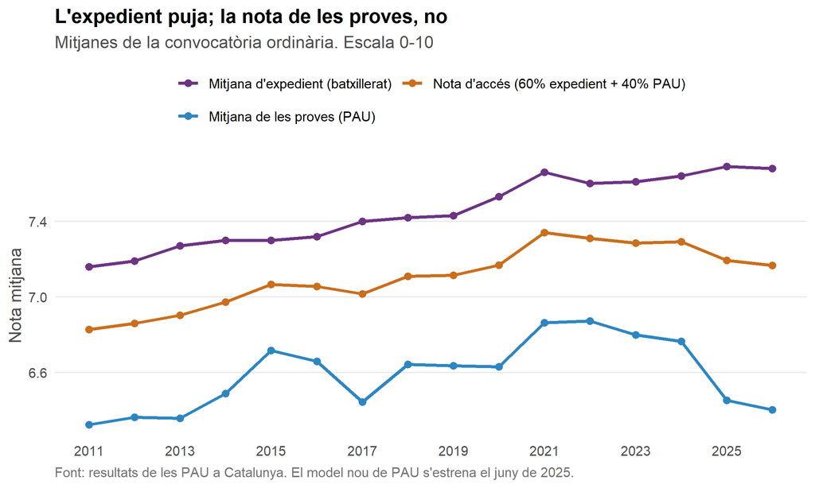

Figura 7

I aquí apareix el matís important. La **mitjana d’expedient de batxillerat** sí que puja de forma sostinguda (de 7,32 a 7,69, 0,37 punts més): és el patró que se sol anomenar *inflació de notes*. En canvi, la **mitjana de les proves** no acompanya —de fet, baixa 0,21 punts— i la distància entre les dues creix. Com que la nota d’accés pondera l’expedient (60%) i la prova (40%), el resultat net és una millora molt modesta: la **nota d’accés mitjana** només puja 0,14 punts en tota la dècada.

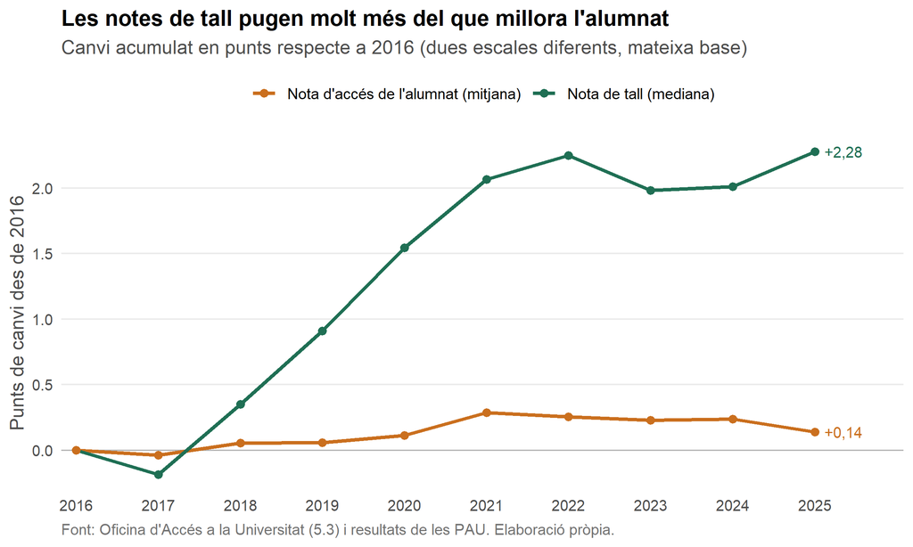

Figura 8

La comparació és contundent. Entre 2016 i 2025 la mediana de la nota de tall ha pujat **2,28 punts**, mentre que la nota d’accés mitjana de l’alumnat només ha pujat **0,14**. Encara que atribuíssim tota aquesta millora a l’alumnat, explicaria aproximadament un **6%** de la pujada del llistó. La resta és competència.

El darrer any ho deixa encara més clar: amb el **model nou de PAU** (estrenat el juny de 2025), la nota d’accés mitjana ha **baixat** 0,10 punts respecte a 2024 i, tot i així, la mediana de la nota de tall ha **pujat** 0,27 punts. Si el motor fos la inflació de notes, hauria d’haver passat exactament el contrari.

En resum: l’alumnat que es presenta a les PAU és **més nombrós**, i això empeny la demanda; però **no és prou millor** com per explicar unes notes de tall que pugen moltes vegades més de pressa. La nota de tall no mesura el nivell de l’alumnat: mesura **quanta gent es queda fora**.

## La cadena causal

> **Més sol·licitants** competint per **una oferta de places estable** → **més pressió per plaça** → **notes de tall més altes** i **menys estudis sense demanda**.

Les notes de les PAU encaixen en aquesta cadena **pel costat de la demanda** (cada cop hi ha més presentats), no pel de les notes: la millora de l’expedient és massa petita, i massa compensada per unes proves que no pugen, per moure el llistó per si sola.

L’excedent de demanda que no cap al sistema públic presencial es desplaça, en bona part, cap a altres vies (universitats privades i, molt especialment, la UOC), però aquesta és una altra història que queda fora de l’abast d’aquest informe.

## Nota metodològica

- **Abast**: sistema públic de preinscripció de Catalunya (les 7 universitats públiques, la UVic-UCC i els centres adscrits). No s’hi inclouen universitats privades ni la UOC.
- **Fonts** (pestanyes dels fitxers `Dades_20XX.xlsx` de l’Oficina d’Accés a la Universitat):
  - *Sol·licitants en 1a preferència* (juny): pestanya **1.1.6**, un valor per any (2020–2025).
  - *Places de preinscripció*: pestanya **1.1.5**, un valor per any (2020–2025). No s’ha fet servir la pestanya 4.4 per al total perquè, als fitxers anteriors a 2023, repeteix cada estudi en diversos blocs i en duplica la suma.
  - *Matrícula de nou accés*: pestanya **7.5**, fila «Total universitats que participen» (2016–2025).
  - *Notes de tall*: pestanya **5.3** (2016–2025).
- **Punt provisional de 2026** (sol·licitants, places i ràtio): el fitxer `Dades_2026.xlsx` encara no s’ha publicat, així que el 2026 surt del **Dossier de preinscripció 2026** (Departament de Recerca i Universitats, juliol de 2026), l’únic disponible. Els seus totals no casen del tot amb els de les pestanyes: per a 2025 dóna 62.238 sol·licitants i 41.866 places, davant dels 63.038 i 41.801 de 1.1.6/1.1.5. En el cas de les **places** no és cap diferència real (5 de 8 universitats quadren a la plaça exacta; el desajust és només com es reparteixen els graus compartits). En el dels **sol·licitants** (−1,3%) és una qüestió de **moment de tall**: la pestanya 1.1.6 és el recompte «al tancament» i el dossier n’és una instantània anterior. Per no crear un salt artificial, el punt de 2026 **no es copia tal qual** sinó que **s’enllaça** la variació interanual del dossier (−4%) sobre el nivell ferm de 2025; així estima el que dirà el fitxer definitiu. Als gràfics es marca a part (punt buit / barra clara) i **no entra en cap altre càlcul** de l’informe.
- **Notes de tall de 2026** (provisional): surten del PDF de notes de tall de la **1a assignació** (2026) de l’OAU, extret amb `02-code/extract_notes_tall_pdf.py` cap a `01-dades/notes_tall_1a_2026.csv` (555 estudis). A diferència dels sol·licitants, aquí **no hi ha canvi de base**: la pestanya 5.3 històrica també són notes de 1a assignació (comprovat, casa a la mil·lèsima amb el 2025), de manera que aquest punt amplia la sèrie directament. Es marca com a provisional només perquè encara no és al fitxer `Dades` definitiu.
- **PAU**: fitxer `01-dades/pau_cat_resultats_2010_2025.csv` (convocatòria ordinària de juny, Catalunya). Els cursos s’han datat per l’**any de les proves** —el curs 2024/25 són les PAU del juny de 2025—, que és l’any que casa amb la preinscripció d’aquell estiu. La sèrie va, doncs, de 2011 a 2026.
- **Notes de tall**: els buits corresponen a estudis no oferts aquell any i s’exclouen. Els valors inferiors a 5,0 d’alguns anys inicials són anòmals respecte a l’escala 5–14 i es tracten com a terra (5,0). Es resumeixen amb la **mediana** i el rang interquartílic per no deixar-se distorsionar pels canvis de composició de l’oferta.
- **Comparació tall / nota d’accés**: són dues magnituds diferents i la comparació és indicativa, no una descomposició exacta. La nota de tall és una **nota d’admissió** (escala 5–14, hi compten les matèries de ponderació) i es refereix a **l’últim admès** de cada estudi; la nota d’accés mitjana és una **mitjana de tot el col·lectiu** (escala 0–10) i només cobreix la via de batxillerat. Per això es comparen com a **canvis en punts respecte a l’any base**, en comptes de nivells, i el 6% esmentat és un ordre de magnitud —de fet, una **fita superior** generosa: una millora general de les notes es trasllada al llistó com a molt punt per punt, i la nota d’accés només pesa una part de la d’admissió.
- **Reproduïbilitat**: tot el processament és a `02-code/` (`Rscript 02-code/run_analysis.R`) i les dades tidy resultants a `04-output/series_2016_2025.csv`.

Sèries resultants (buits = fora de la finestra de la sèrie). El 2026 és provisional: sol·licitants/places/ràtio (dossier, enllaçat) i notes de tall (1a assignació). Les PAU arriben fins al 2026 de ple dret.

| year | estudis_infrademandats | matricula_nou_acces | nota_tall_mediana | nota_tall_mitjana | pau_mitjana_acces | pau_mitjana_expedient | pau_mitjana_pau | pau_presentats | pct_tall_ge_10 | pct_tall_ge_11 | pct_tall_ge_12 | pct_tall_ge_6 | pct_tall_ge_7 | pct_tall_ge_8 | pct_tall_ge_9 | places | ratio_sol_plaça | solicitants_1a_pref |
| --- | --- | --- | --- | --- | --- | --- | --- | --- | --- | --- | --- | --- | --- | --- | --- | --- | --- | --- |
| 2.011 | NA | NA | NA | NA | 6,828 | 7,16 | 6,324 | 24.152 | NA | NA | NA | NA | NA | NA | NA | NA | NA | NA |
| 2.012 | NA | NA | NA | NA | 6,860 | 7,19 | 6,364 | 24.573 | NA | NA | NA | NA | NA | NA | NA | NA | NA | NA |
| 2.013 | NA | NA | NA | NA | 6,903 | 7,27 | 6,359 | 24.728 | NA | NA | NA | NA | NA | NA | NA | NA | NA | NA |
| 2.014 | NA | NA | NA | NA | 6,973 | 7,30 | 6,489 | 25.515 | NA | NA | NA | NA | NA | NA | NA | NA | NA | NA |
| 2.015 | NA | NA | NA | NA | 7,067 | 7,30 | 6,717 | 25.863 | NA | NA | NA | NA | NA | NA | NA | NA | NA | NA |
| 2.016 | 206 | 38.233 | 5,924 | 6,959 | 7,056 | 7,32 | 6,660 | 26.099 | 13,675 | 9,402 | 4,274 | 49,359 | 40,598 | 29,487 | 19,658 | NA | NA | NA |
| 2.017 | 219 | 38.680 | 5,738 | 7,012 | 7,017 | 7,40 | 6,445 | 26.769 | 13,836 | 10,273 | 4,403 | 48,428 | 42,558 | 32,495 | 20,755 | NA | NA | NA |
| 2.018 | 191 | 39.352 | 6,272 | 7,173 | 7,110 | 7,42 | 6,643 | 27.805 | 15,102 | 11,429 | 4,898 | 52,449 | 43,673 | 34,286 | 23,469 | NA | NA | NA |
| 2.019 | 191 | 39.378 | 6,832 | 7,395 | 7,114 | 7,43 | 6,637 | 28.301 | 19,085 | 12,127 | 4,970 | 56,262 | 48,708 | 38,569 | 28,429 | NA | NA | NA |
| 2.020 | 171 | 39.850 | 7,467 | 7,775 | 7,169 | 7,53 | 6,631 | 31.629 | 23,256 | 16,473 | 8,140 | 61,047 | 53,295 | 45,543 | 36,240 | 40.213 | 1,388 | 55.815 |
| 2.021 | 162 | 40.674 | 7,990 | 8,069 | 7,341 | 7,66 | 6,863 | 31.711 | 28,626 | 19,084 | 9,733 | 65,267 | 58,779 | 49,809 | 39,695 | 40.324 | 1,424 | 57.411 |
| 2.022 | 159 | 41.151 | 8,174 | 8,129 | 7,311 | 7,60 | 6,872 | 32.051 | 28,810 | 18,773 | 9,108 | 67,472 | 60,781 | 51,301 | 40,149 | 41.305 | 1,429 | 59.038 |
| 2.023 | 131 | 41.759 | 7,906 | 8,051 | 7,285 | 7,61 | 6,799 | 32.638 | 26,111 | 14,815 | 7,037 | 70,185 | 61,296 | 49,074 | 38,148 | 41.517 | 1,398 | 58.023 |
| 2.024 | 148 | 42.093 | 7,936 | 8,014 | 7,293 | 7,64 | 6,765 | 33.092 | 26,000 | 15,091 | 5,273 | 70,000 | 62,000 | 48,909 | 37,273 | 41.771 | 1,412 | 58.975 |
| 2.025 | 138 | 42.090 | 8,203 | 8,101 | 7,193 | 7,69 | 6,453 | 33.707 | 25,946 | 14,775 | 5,586 | 70,450 | 64,685 | 52,793 | 38,378 | 41.801 | 1,508 | 63.038 |
| 2.026 | 147 | NA | 8,160 | 8,030 | 7,167 | 7,68 | 6,403 | 34.642 | 22,939 | 12,007 | 3,943 | 70,968 | 65,412 | 53,047 | 37,455 | 41.807 | 1,445 | 60.420 |